# COVID-19 Pandemic in Mauritius

AS2019577

10/7/2022

# 1. Introduction

Mauritius is a part of the Mascarene Islands in the Indian Ocean, located off the eastern coast of Africa. The capital of Mauritius is Port Louis.The population density in Mauritius is the highest of African countries and the current population of Mauritius is 1,276,532 as of Friday, October 7, 2022, based on Worldometer elaboration of the latest United Nations data.Mauritius population is equivalent to 0.02% of the total world population.The birth rate remains well below the world average, while the death rate is similar to the world average. Life expectancy is about 70 years for men and more than 75 years for women is higher than the world average and it is well above the average for African countries. About two-fifths of the country’s population is younger than age 30.

The climate is maritime subtropical, with fairly uniform temperature throughout the year. Mean temperatures vary from the mid-70s F (low to mid-20s C) at sea level to the upper 60s F (upper 10s C) on the high plateau. Two seasons are recognized: hot (December to April) and cool (June to September). Annual rainfall varies from around 35 inches (900 mm) on the west coast to 60 inches (1,525 mm) on the southeast coast and about 200 inches (5,080 mm) on the central plateau.

# Location of Mauritius

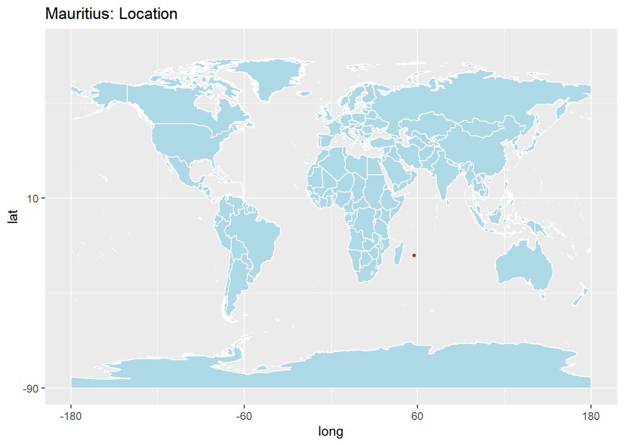

Mauritius lies about 500 miles (800 km) east of Madagascar in the Indian Ocean. Its outlying territories are Rodrigues Island, situated about 340 miles (550 km) eastward, the Cargados Carajos Shoals, 250 miles (400 km) northeastward, and the Agalega Islands, 580 miles (930 km) northward from the main island.

The State of Mauritius was hit by the COVID-19 pandemic in March 2020. Since the first three cases were confirmed, the Government of Mauritius took a series of bold measures to protect the population while formulating appropriate national development policies.

A national confinement protocol was applied from 19 March to 15 June 2020 with the objective to protect citizens and slow the spread of the virus. The State of Mauritius has started its national vaccination campaign against COVID-19 since 26 January 2021 .

# 2. Exploratory Data Analysis

# Visualization of confirmed cases in Mauritius

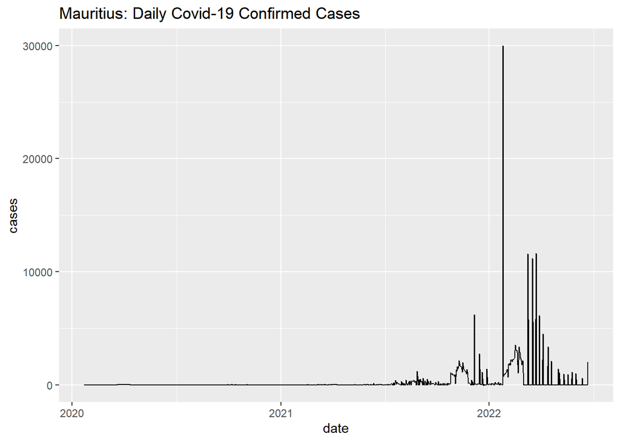

# Visualization of death cases in Mauritius

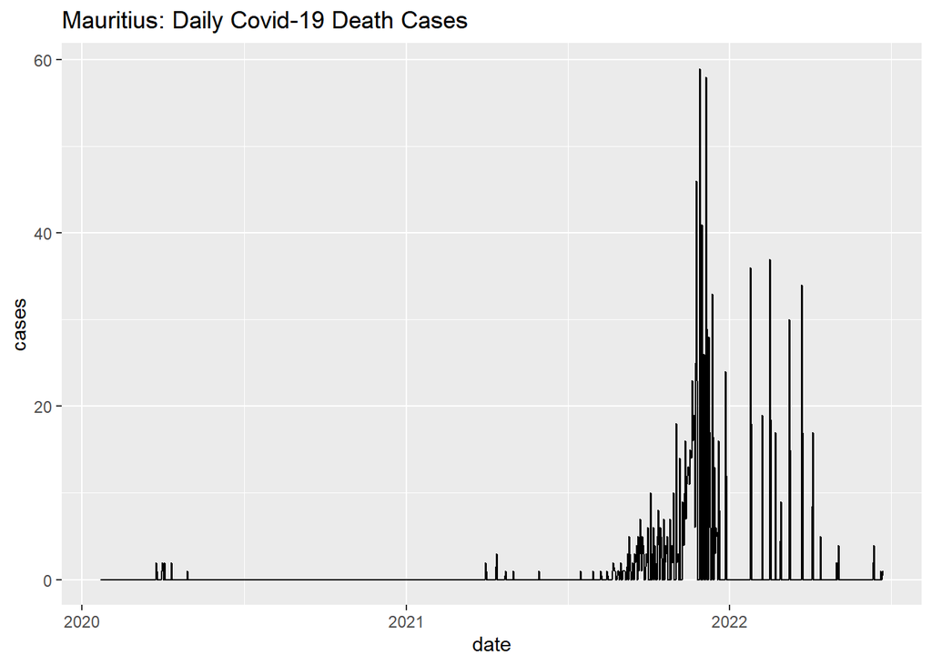

The number of COVID-19 death by COVID-19 in Mauritius are shown by this figure.It is also increasing from 2021 to 2022.In the end of 2021, the maximum death cases has been reported.

# Visualization of recovered cases in Mauritius

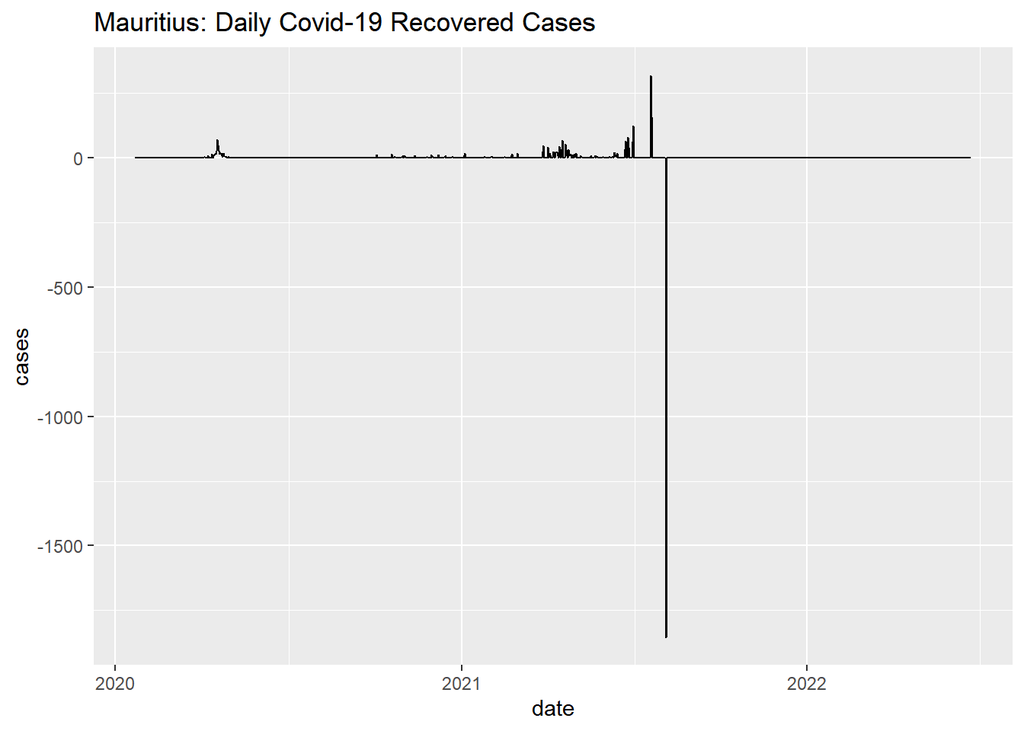

This figure implies that number of recovered Cases form Corona Virus in Mauritius from 2020 to 2022.According to this figure the recovery cases has not been reported in 2022.But befor 2022, the recovery cases are increasing.

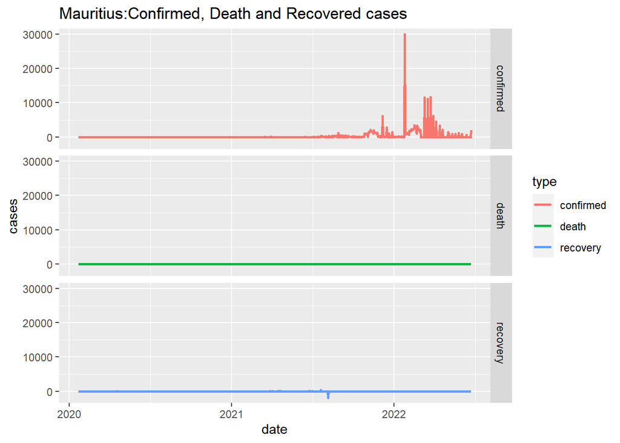

This shows that the confirmed cases is high ,the recovery cases is low.

# The COVID-19 cases in Mauritius comparison with the neighbouring countries

Mauritius is geographically close to Madagascar, Réunion, and the Seychelles. Mozambique and South Africa are the close counties to Mauritius.Therefore it can be compare the COVID-19 cases in Mauritius with those countries.

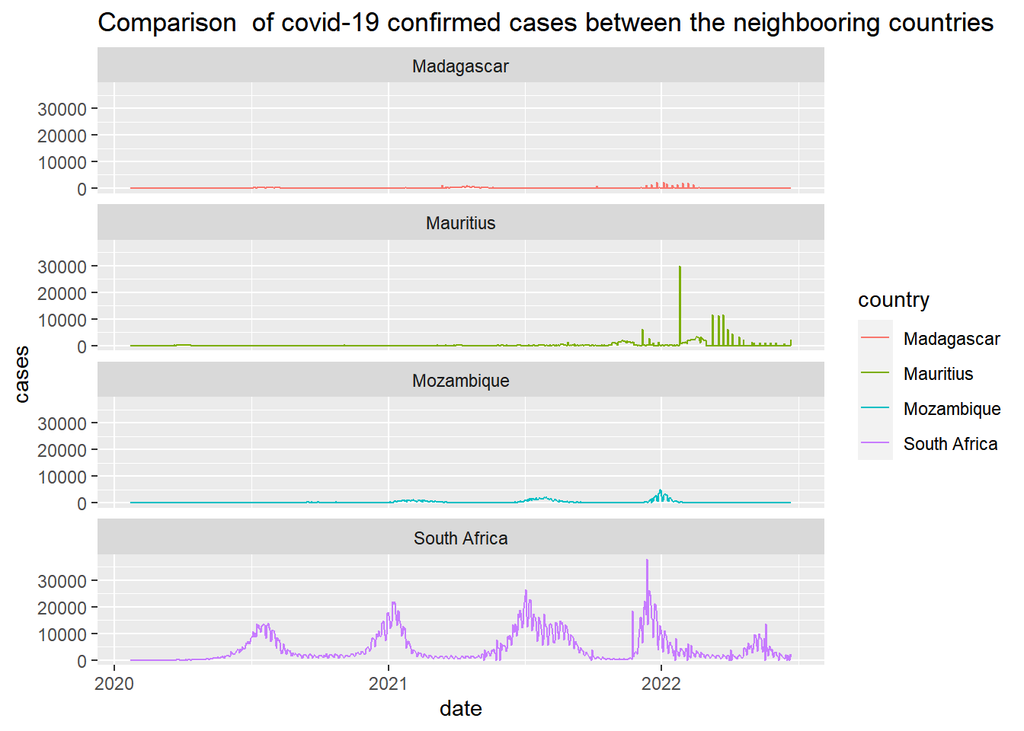

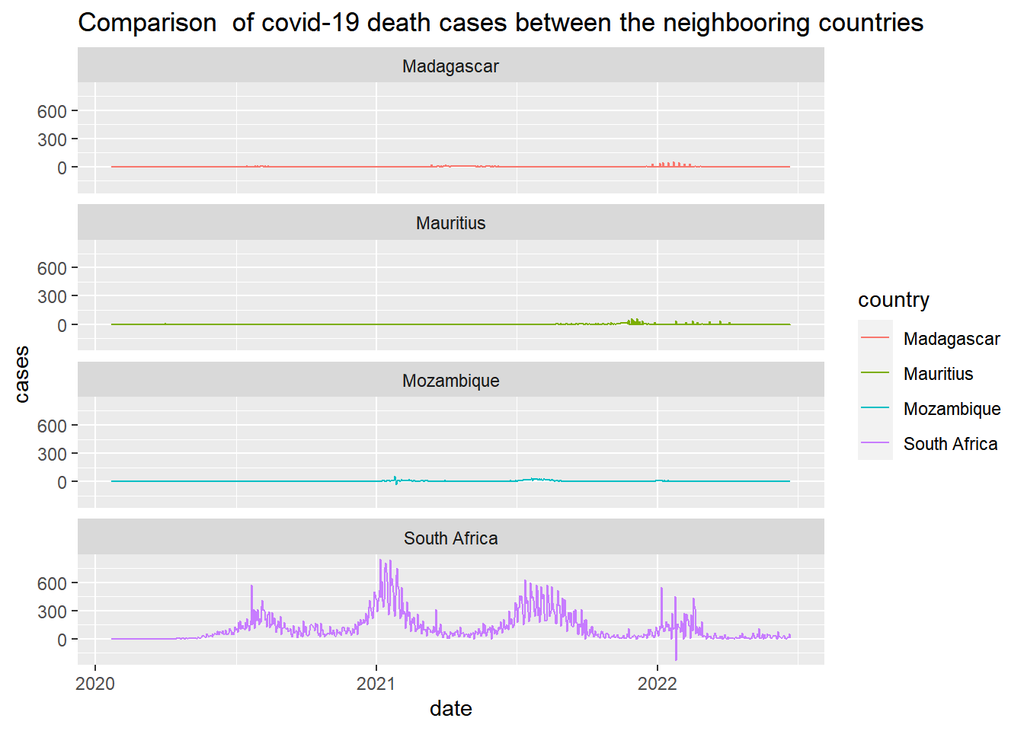

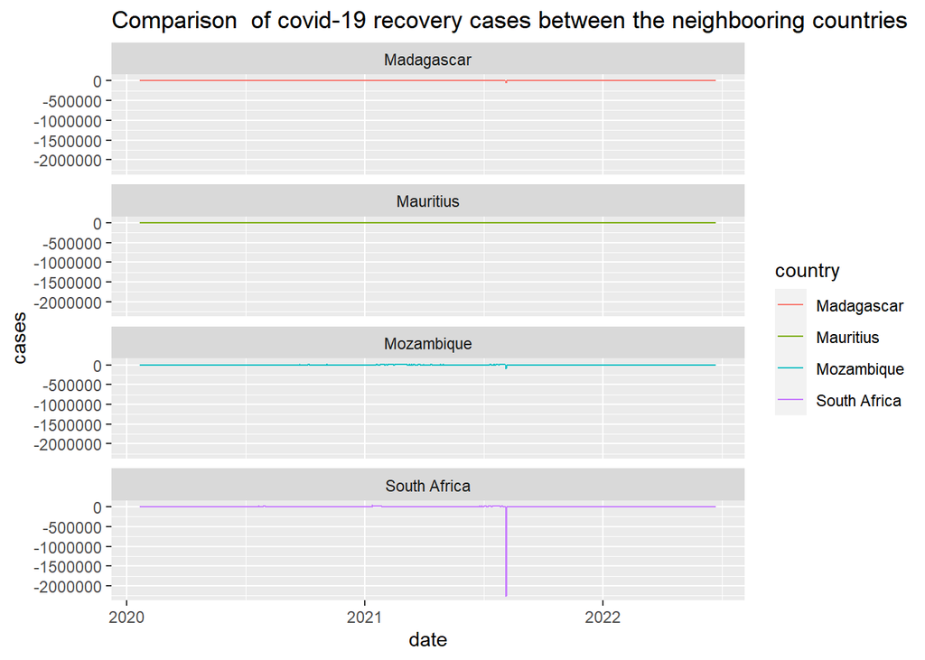

This figure shows that the recovery cases of South Africa, Mozambique, Madagascar and Miuritius from 2020 to 2022.There is no significant recovery cases in all these countries.

# 3.Conclusion and Discussion

# 4.References

- https://www.britannica.com/place/Mauritius
- https://www.worldometers.info/world-population/mauritius-population
- https://www.nationsonline.org/oneworld/map/google_map_mauritius